# Lecture 4: Defining custom functions and standardizing data

## Introduction

On day 3 of the morning lectures (Lecture 6), you see a graph of Earned Run Average (ERA) against year, along with a line connecting the average ERA in each year.

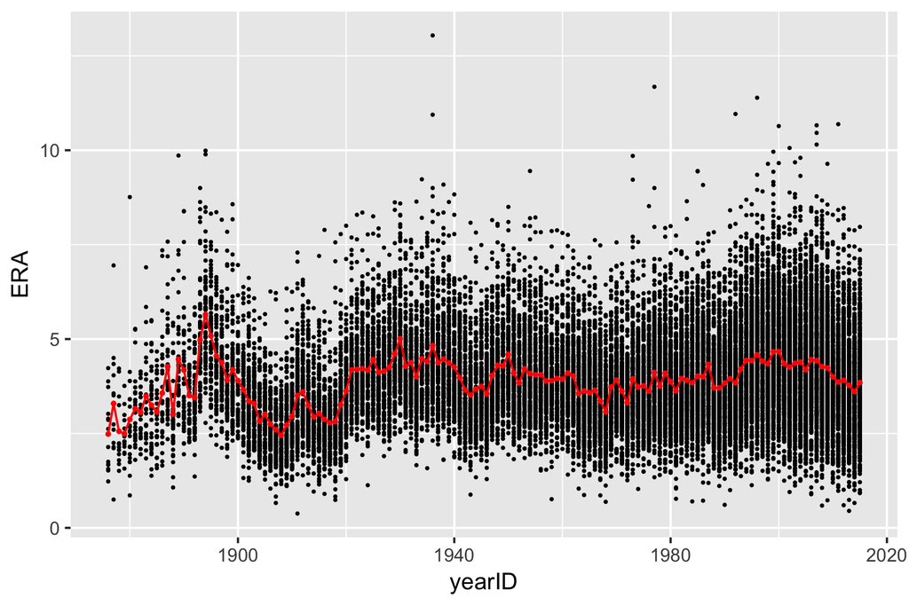

## The Lahman Baseball Database

```r
install.packages("Lahman")
```

Once the package is installed, we can load it into R along with the tidyverse packages:

```r
library(tidyverse)
library(Lahman)
```

As we know, many packages not only contain new functions, but also new datasets. Whenever we load a package, the datasets that are part of the package get implicitly loaded into the background. To see which datasets come with the Lahman package, we use the `data()` function.

```r
data(package = "Lahman")
```

This will open up a new window with all of the names of the datasets contained in the Lahman package. Today, we will specifically be focusing on the dataset called `Pitching`, which contains season-level statistics on all pitchers going all the way back to 1871. Let’s load this dataset as a tibble (which is easier to read than the default data.frame) called `pitching`.

```r
pitching <- as_tibble(Pitching)
pitching
```

```
## # A tibble: 51,368 × 30
##    playerID  yearID stint teamID lgID      W     L     G    GS    CG   SHO    SV IPouts     H    ER
##    <chr>      <int> <int> <fct>  <fct> <int> <int> <int> <int> <int> <int> <int>  <int> <int> <int>
##  1 aardsda01   2004     1 SFN    NL        1     0    11     0     0     0     0     32    20     8
##  2 aardsda01   2006     1 CHN    NL        3     0    45     0     0     0     0    159    41    24
##  3 aardsda01   2007     1 CHA    AL        2     1    25     0     0     0     0     97    39    23
##  4 aardsda01   2008     1 BOS    AL        4     2    47     0     0     0     0    146    49    30
##  5 aardsda01   2009     1 SEA    AL        3     6    73     0     0     0    38    214    49    20
##  6 aardsda01   2010     1 SEA    AL        0     6    53     0     0     0    31    149    33    19
##  7 aardsda01   2012     1 NYA    AL        0     0     1     0     0     0     0      3     1     1
##  8 aardsda01   2013     1 NYN    NL        2     2    43     0     0     0     0    119    39    19
##  9 aardsda01   2015     1 ATL    NL        1     1    33     0     0     0     0     92    25    16
## 10 aasedo01    1977     1 BOS    AL        6     2    13    13     4     2     0    277    85    32
## # ℹ 51,358 more rows
## # ℹ 15 more variables: HR <int>, BB <int>, SO <int>, BAOpp <dbl>, ERA <dbl>, IBB <int>, WP <int>,
## #   HBP <int>, BK <int>, BFP <int>, GF <int>, R <int>, SH <int>, SF <int>, GIDP <int>
```

There are tons of rows and columns in the dataset. For this exercise, we will only want to focus on ERA and also focus only on those pitchers who have pitched at least 150 innings. Unfortunately, the Lahman pitching dataset does not contain the number of innings pitched (IP). Instead, it has a column called “IPouts”, which is the number of outs pitched and whose formula is $\text{IPOuts} = 3 \times \text{IP}.$

Using the pipe and the dplyr verbs we learned in Lecture 2, we will create a new dataset called `pitching` (we make it all lowercase to differentiate from the original Lahman `Pitching` dataset), then add the “IP” column, filter the data to include only all players who pitched at least 150 innings and played in either the AL or the NL, and select only the columns corresponding to the player, year, team, league, innings pitched, and ERA.

```r
pitching <- pitching %>%
  mutate(IP = IPouts/3) %>%
  filter(lgID %in% c('AL', 'NL') & IP >= 150) %>%
  select(playerID, yearID, teamID, lgID, IP, ERA)
pitching
```

```
## # A tibble: 9,688 × 6
##    playerID  yearID teamID lgID      IP   ERA
##    <chr>      <int> <fct>  <fct>  <dbl> <dbl>
##  1 aasedo01    1978 CAL    AL    178.67  4.03
##  2 aasedo01    1979 CAL    AL    185.33  4.81
##  3 aasedo01    1980 CAL    AL    175     4.06
##  4 abbeybe01   1892 WAS    NL    195.67  3.45
##  5 abbeybe01   1896 BRO    NL    164.33  5.15
##  6 abbotgl01   1977 SEA    AL    204.33  4.45
##  7 abbotgl01   1978 SEA    AL    155.33  5.27
##  8 abbotgl01   1980 SEA    AL    215     4.1
##  9 abbotji01   1989 CAL    AL    181.33  3.92
## 10 abbotji01   1990 CAL    AL    211.67  4.51
## # ℹ 9,678 more rows
```

Now that we have ERA for all pitchers eligible for our analysis, we can plot the ERAs by year.

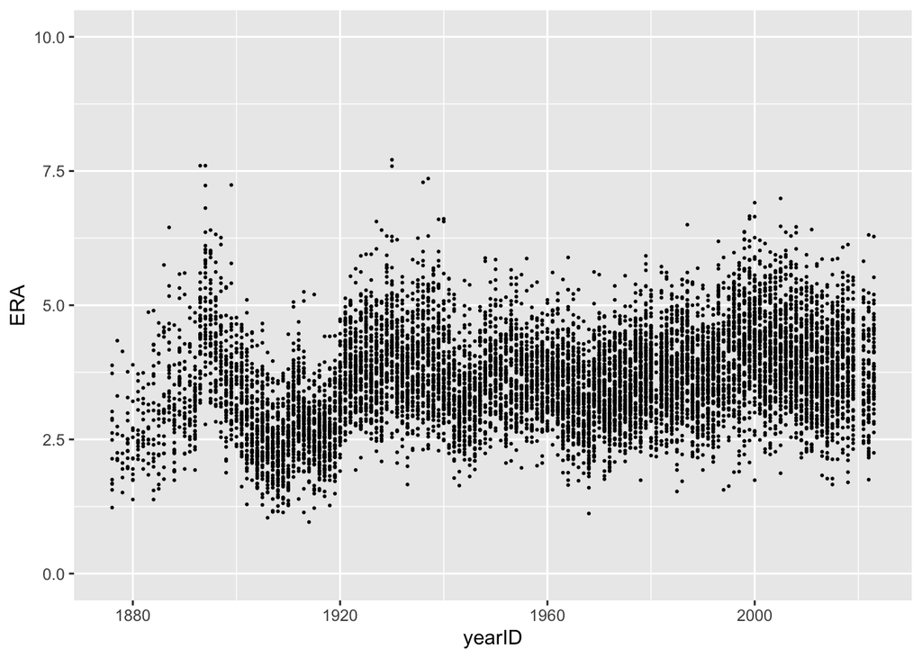

```r
ggplot(data = pitching) +
  ylim(0, 10) +
  geom_point(mapping = aes(x = yearID, y = ERA), size = 0.3)
```

Looking at the plot, it appears that some of the pitchers from the first few decades of baseball had the lowest ERA. Using `arrange()`, we can see which pitcher had the best season according to ERA.

```r
arrange(pitching, ERA)
```

```
## # A tibble: 9,688 × 6
##    playerID  yearID teamID lgID      IP   ERA
##    <chr>      <int> <fct>  <fct>  <dbl> <dbl>
##  1 leonadu01   1914 BOS    AL    224.67  0.96
##  2 brownmo01   1906 CHN    NL    277.33  1.04
##  3 gibsobo01   1968 SLN    NL    304.67  1.12
##  4 johnswa01   1913 WS1    AL    346     1.14
##  5 mathech01   1909 NY1    NL    275.33  1.14
##  6 pfiesja01   1907 CHN    NL    195     1.15
##  7 jossad01    1908 CLE    AL    325     1.16
##  8 lundgca01   1907 CHN    NL    207     1.17
##  9 alexape01   1915 PHI    NL    376.33  1.22
## 10 bradlge01   1876 SL3    NL    573     1.23
## # ℹ 9,678 more rows
```

It would appear that the best pitching season of all time was Dutch Leonard’s 1914 season with the Red Sox. The next best was [Mordecai Brown](https://en.wikipedia.org/wiki/Mordecai_Brown)’s 1906 season with the Cubs. How much better was Leonard’s 0.96 ERA than Brown’s 1.04 ERA?

To answer this, we can transform ERA to standardized units using the `mutate()` function. There is a minor complication: there is not a built-in function for standardizing a variable in R! Luckily for us, R allows us to define our own functions like so:

```r
standardize <- function(x){
  mu <- mean(x, na.rm = TRUE)
  sigma <- sd(x, na.rm = TRUE)
  return( (x - mu)/sigma )
}
```

The `na.rm = TRUE` arguments tell R to ignore missing values when computing the mean and standard deviation. Armed with our `standardize()` function, we can add a column called zERA_all which transforms ERA to the standardized scale.

```r
pitching <-
  pitching %>%
  mutate(zERA_all = standardize(ERA))
pitching %>% arrange(zERA_all)
```

```
## # A tibble: 9,688 × 7
##    playerID  yearID teamID lgID      IP   ERA zERA_all
##    <chr>      <int> <fct>  <fct>  <dbl> <dbl>    <dbl>
##  1 leonadu01   1914 BOS    AL    224.67  0.96  -3.0115
##  2 brownmo01   1906 CHN    NL    277.33  1.04  -2.9207
##  3 gibsobo01   1968 SLN    NL    304.67  1.12  -2.8299
##  4 johnswa01   1913 WS1    AL    346     1.14  -2.8072
##  5 mathech01   1909 NY1    NL    275.33  1.14  -2.8072
##  6 pfiesja01   1907 CHN    NL    195     1.15  -2.7958
##  7 jossad01    1908 CLE    AL    325     1.16  -2.7845
##  8 lundgca01   1907 CHN    NL    207     1.17  -2.7731
##  9 alexape01   1915 PHI    NL    376.33  1.22  -2.7164
## 10 bradlge01   1876 SL3    NL    573     1.23  -2.7050
## # ℹ 9,678 more rows
```

Now we see that Leonard’s 0.96 ERA was about 3 standard deviations below the overall mean of qualified pitchers, while Brown’s was about 2.91 standard deviations below the mean. On the other hand, the ostensibly worst pitching season was Philadelphia’s own [Les Sweetland](https://en.wikipedia.org/wiki/Les_Sweetland) in 1930. Incidentally enough, Sweetland started that season with a three-hit shutout! Check out this [ESPN blog post](http://www.espn.com/blog/sweetspot/post/_/id/48687/the-amazing-1930-philadelphia-phillies) about the 1930’s Phillies pitching staff.

Of course, you might argue that comparing the raw ERAs across the various years is somewhat unfair. After all, the game as it was played in 1914 is very different to the one played today! As such, it may be more appropriate to standardize all of the ERAs within each season separately. To do this, we will have to compute the mean and standard deviation of ERAs within each season.

## Grouped calculations

Very often in a data analysis, instead of performing a calculation on the entire data set, you’ll want to first *split* the data into smaller subsets, *apply* the same calculation on every subset, and then *combine* the results from each subset. For example, in order to replicate the figure above from Prof. Wyner’s lecture, we need to split our pitching dataset based on the year, compute the average ERA within each year, and then combine these into a single tibble.

One strength of dplyr is the ease with which you can follow this “split-apply-combine” paradigm using the function `group_by()`. We can use this in concert with the pipe as follows:

```r
pitching <- pitching %>%
  group_by(yearID)
```

When we print out `pitching` now, we notice an extra line that tells us the grouping variable. Now when we pass this dataset on to subsequent calculations, these calculations will be done on each group.

We can now summarize each season using another `tidyverse` function called… `reframe()`! This convenient function will compute summary statistics that we specify with respect to the groups from `group_by()`. For instance, we can compute the average ERA in each year in the following way:

```r
pitching %>%
  reframe(ave_ERA = mean(ERA))
```

```
## # A tibble: 147 × 2
##    yearID ave_ERA
##     <int>   <dbl>
##  1   1876  2.4246
##  2   1877  2.7843
##  3   1878  2.3229
##  4   1879  2.5708
##  5   1880  2.3317
##  6   1881  2.7586
##  7   1882  2.7607
##  8   1883  2.79
##  9   1884  3.0405
## 10   1885  2.8732
## # ℹ 137 more rows
```

The following functions are quite useful for summarizing several aspects of the distribution of the variables in our dataset:

- Center: `mean()`, `median()`
- Spread: `sd()`, `IQR()`
- Range: `min()`, `max()`
- Count: `n()`, `n_distinct()`

We’ll now create a dataset, `pitching_summary`, that contains the mean and standard deviation of ERA **within each year**:

```r
pitching_summary <- pitching %>%
  reframe(mean = mean(ERA),
            sd = sd(ERA))
```

One of the most commonly used functions, `n()`, returns counts and is especially useful when used on a grouped dataset We can, for instance, count the number of pitchers in our dataset within each year using `n()`.

```r
pitching %>%
  reframe(count = n()) %>%
  arrange(count)
```

```
## # A tibble: 147 × 2
##    yearID count
##     <int> <int>
##  1   1877     7
##  2   1878     7
##  3   1880    12
##  4   1876    13
##  5   1879    13
##  6   1883    13
##  7   1881    14
##  8   1882    14
##  9   1884    19
## 10   1885    19
## # ℹ 137 more rows
```

Or equivalently, we can use the `count` function:

```r
pitching %>%
  count() %>%
  arrange(n)
```

```
## # A tibble: 147 × 2
## # Groups:   yearID [147]
##    yearID     n
##     <int> <int>
##  1   1877     7
##  2   1878     7
##  3   1880    12
##  4   1876    13
##  5   1879    13
##  6   1883    13
##  7   1881    14
##  8   1882    14
##  9   1884    19
## 10   1885    19
## # ℹ 137 more rows
```

What’s the difference between the two approaches above?

For example, the code below keeps only the rows where there are at least 90 pitchers and then sorts those rows from largest count to smallest.

```r
pitching %>%
  reframe(count = n()) %>%
  filter(count >= 90) %>%
  arrange(desc(count))
```

Once we add a grouping to our dataset, it also changes the way `mutate()` operates on it. We can now standardize each pitcher’s ERA within each year and store that result in a column called z_era_year.

```r
pitching <- pitching %>%
  mutate(z_era_year = standardize(ERA))
pitching %>% arrange(z_era_year)
```

```
## # A tibble: 9,688 × 8
## # Groups:   yearID [147]
##    playerID  yearID teamID lgID      IP   ERA zERA_all z_era_year
##    <chr>      <int> <fct>  <fct>  <dbl> <dbl>    <dbl>      <dbl>
##  1 leonadu01   1914 BOS    AL    224.67  0.96  -3.0115    -3.4806
##  2 martipe02   2000 BOS    AL    217     1.74  -2.1261    -3.1600
##  3 maddugr01   1995 ATL    NL    209.67  1.63  -2.2510    -3.0197
##  4 luquedo01   1923 CIN    NL    322     1.93  -1.9104    -2.8833
##  5 martipe02   1999 BOS    AL    213.33  2.07  -1.7515    -2.8549
##  6 brownke01   1996 FLO    NL    233     1.89  -1.9558    -2.8244
##  7 eichhma01   1986 TOR    AL    157     1.72  -2.1488    -2.8135
##  8 maddugr01   1994 ATL    NL    202     1.56  -2.3304    -2.7881
##  9 piercbi02   1955 CHA    AL    205.67  1.97  -1.8650    -2.7718
## 10 hubbeca01   1933 NY1    NL    308.67  1.66  -2.2169    -2.7658
## # ℹ 9,678 more rows
```

### Ungrouping and grouping on multiple variables

As we just saw, when we add a grouping to a dataset, it affects how verbs like `reframe()` and `mutate()` operate on our data. It is sometimes the case that we wish to remove the grouping and let these verbs (and others) operate on the entire dataset again. To remove the grouping, we have to use the `ungroup()` function. Remember, as with the other `tidyverse` verbs we’ve learned, we need to store the result if we want the dataset to remain ungrouped!

```r
pitching <- pitching %>%
  ungroup()
```

To verify that we’ve indeed removed the grouping, let’s re-run the code from above to compute the mean and standard deviation of ERA.

```r
pitching %>% reframe(mean = mean(ERA), sd = sd(ERA))
```

```
## # A tibble: 1 × 2
##     mean      sd
##    <dbl>   <dbl>
## 1 3.6130 0.88096
```

```r
pitching <- pitching %>%
  group_by(yearID, lgID) %>%
  mutate(z_era_year_lg = standardize(ERA),
         count = n())
```

When we arrange by the ERA standardized within the year and league, we now see that Pedro Martinez’s 1999 and 2000 season with the Red Sox were even better than Dutch Leonard’s 1914 season!

```r
pitching %>%
  arrange(z_era_year_lg)
```

```
## # A tibble: 9,688 × 10
## # Groups:   yearID, lgID [269]
##    playerID  yearID teamID lgID      IP   ERA zERA_all z_era_year z_era_year_lg count
##    <chr>      <int> <fct>  <fct>  <dbl> <dbl>    <dbl>      <dbl>         <dbl> <int>
##  1 martipe02   2000 BOS    AL    217     1.74  -2.1261    -3.1600       -3.5508    42
##  2 martipe02   1999 BOS    AL    213.33  2.07  -1.7515    -2.8549       -3.1485    40
##  3 leonadu01   1914 BOS    AL    224.67  0.96  -3.0115    -3.4806       -3.1296    35
##  4 eichhma01   1986 TOR    AL    157     1.72  -2.1488    -2.8135       -3.0643    49
##  5 youngcy01   1901 BOS    AL    371.33  1.62  -2.2623    -2.5119       -2.8087    32
##  6 alexape01   1915 PHI    NL    376.33  1.22  -2.7164    -2.2799       -2.7758    37
##  7 maddugr01   1995 ATL    NL    209.67  1.63  -2.2510    -3.0197       -2.7461    34
##  8 gibsobo01   1968 SLN    NL    304.67  1.12  -2.8299    -2.7347       -2.7460    43
##  9 grovele01   1931 PHA    AL    288.67  2.06  -1.7628    -2.3854       -2.7365    35
## 10 guidrro01   1978 NYA    AL    273.67  1.74  -2.1261    -2.6674       -2.7332    55
## # ℹ 9,678 more rows
```

## Back to the figure

We started this module with a figure similar to one from Professor Wyner’s class that plotted ERAs over time. When we previously ran the following code, we got a plot that’s very similar to the desired one but that is missing the red line showing the average ERA within each season.

```r
ggplot(pitching) +
  geom_point(aes(x = yearID, y = ERA), size = 0.3)
```

To add the red line to our plot, we need to simply re-run the code above but with some additional calls to `geom_line`.

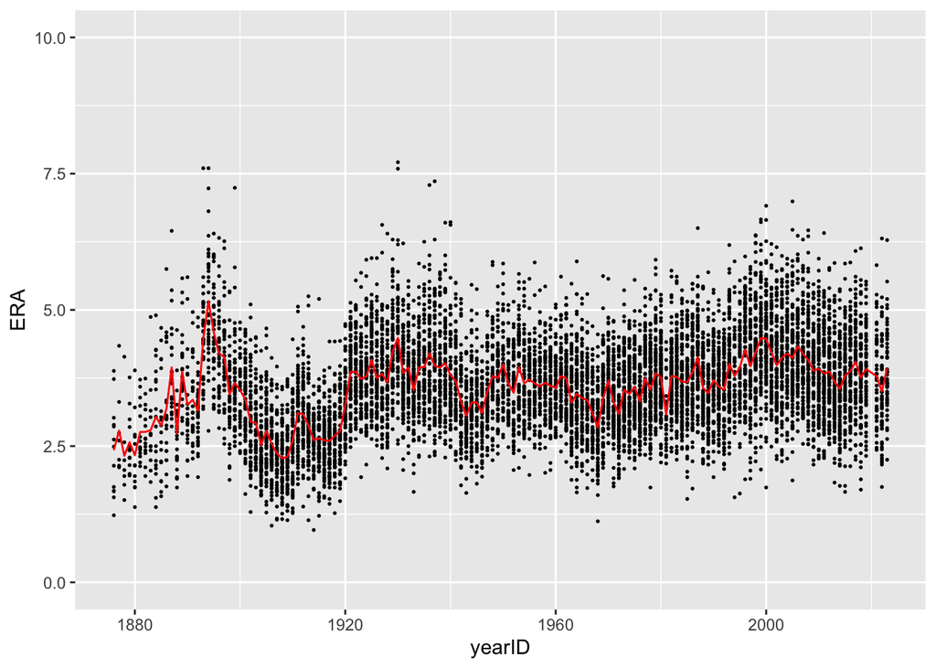

```r
ggplot(pitching) +
  geom_point(aes(x = yearID, y = ERA), size = 0.3) +
  ylim(0, 10) +
  geom_line(data = pitching_summary,
            aes(x = yearID, y = mean), col = 'red')
```

You’ll notice that the last line of code is a bit different than anything we’ve seen before. In particular, we are specifying both the data and mapping within the same ggplot2 function. If all of the information we want to include in the plot is coming from the same data source, it’s enough to just specify the `data` argument in the first line, like we do with `ggplot(data = pitching)` and not in every subsequent call to functions like `geom_point` or `geom_line`. However, whenever we want to add layers to a plot using data from another source (in this case, using data from `pitching_summary` to plot the average ERAs), we need to tell R explicitly and specify the data argument in `geom_line`.